# The impact of school starting age on young people’s well-being and educational performance. Protocol.

Frank Popham & Cristina Iannelli

15 March, 2021

### Introduction

There is international variation in when children start primary schooling with continuing debate about the optimal age (OECD 2016). Some stress the importance of a later start for children to allow them to learn through play for a longer period and to increase their readiness to school. Others instead highlight that children are capable to learn from early ages and that learning basic reading, writing and numeracy skills enable children to get a head start in learning. In addition, there are reasons to believe that the start age of school may matter for social inequalities in educational and well-being outcomes. Since there is often some discretion about the time children can start school, there may be differences in the extent to which parents with different socio-economic resources exercise this discretion, with more socially advantaged parents delaying entry of their children if they deem them too young or not ready for school. Latest figures for Scotland confirm that this is the case here (Scottish Government 2020). If starting school early is detrimental then this disadvantage may be falling disproportionately on the more disadvantaged. On the other hand, an early school starting age may help more disadvantaged children by compensating for their more limited learning resources at home. However, there are potential negative consequences of this choice, as there is evidence that being relatively young in a school year is a disadvantage that could even offset any additional benefit of starting school early. For more advantaged children, at which age they start school and whether they are younger in the year may be less important as home resources can compensate. Suziedelytea and Zhu (2015) found that while early school starting age had positive impacts for cognitive ability in young primary school children in Australia, particularly those disadvantaged, it had negative impacts on social development across the socio-economic spectrum.

#### Background

Children in Scotland are among the youngest in Europe to start school. They usually start when they are between four and a half and five and a half years old. There is a longstanding debate whether this early start may be detrimental for children. Most recently an increase in school starting age to 7 has been advocated following countries such as Finland, a country that performs comparatively well in terms of student outcomes (Scottish Green Party https://greens.scot/news/scottish-greens-kids-should-start-school-at-seven). In Scotland, children whose 5th birthday is between March and August will normally start school in August of the same year while those born between 1 September and the end of February will start in August in the year before they turn 5. These latter children can delay entry to school by a year, with those born in January and February automatically entitled to an extra year of funded nursery provision (this funded provision is dependent on their local council’s approval for those born in September-December). A major part of the Scottish Government’s *“Getting it right for every child”* strategy is improving wellbeing , this wellbeing framework is in turn linked to efforts to improve academic performance and reduce the socio-economic performance gap https://www.gov.scot/policies/girfec/. While much work in Scotland has been conducted on pupils social and emotional wellbeing in recent years and some focus has been paid to school readiness and starting age, most reports are associational rather than having a causal focus (Scottish Government 2018a, 2012) . This is a significant gap as there is consistent evidence from natural experiment studies in other countries that school starting age can affect the likelihood of mental health problems and of a diagnosis of attention deficit hyperactivity disorder (ADHD) (Dee and Sievertsen 2018; Chen, Fortin, and Phipps 2015; Elder 2010; Evans, Morrill, and Parente 2010; Schwandt and Wuppermann 2016). Here it is school starting age affecting relative age within the school year that is the studied mechanism. Most studies assess these effects by socio-economic background finding that impacts across the socio-economic spectrum but sometimes less so in those more advantaged (Dee and Sievertsen 2018; Chen, Fortin, and Phipps 2015; Elder 2010; Evans, Morrill, and Parente 2010). A German study suggests that more educated parents may be more likely to seek an ADHD diagnosis for their young for year child but recognizes their evidence for this is weak (Schwandt and Wuppermann 2016). Crawford et al. (2014) outline the four possible mechanisms through which age at starting school might impact education and wellbeing outcomes: age at test, age of starting school, length of schooling and relative age. As exams are generally taken at the same time, age at test may be an important mechanism. By studying test taken at the same age, they showed that most of the effect of starting age on test performance in England was through age at test. Analysis of England’s PISA test scores (where the sample is age selected so age at test is less of a factor) found little impact of school starting cut-off, this was interpreted as an extra year of schooling (length of schooling) having little effect (Luyten, Peschar, and Coe 2008; Benton 2014). It could also be driven by age of starting school or relative age effects or a combination of all three offsetting. Luyten et al. (2008) suggest that any positive effect of being in a higher grade was greatest in more disadvantaged pupils. This raises the possibility of a trade off between better test scores and worse mental wellbeing especially for disadvantaged pupils. However, a regression discontinuity study from England found that an earlier school start improved performance and reduced the socio-economic gap for both academic performance and “non-cognitive” outcomes although by age 11 the academic effects had worn off (Cornelissen and Dustmann 2019).

#### Research questions

1. Does starting school at an older age improve academic performance and well-being at age 15?
2. Does the starting school age matter for social inequalities in educational and well-being outcomes?

### Method

#### Design

One possible way to study the effect of school starting age would be to compare those who defer entry to those who do not. However, as already described there are a number of differences between those who defer and those that do not in terms of own and parental background, which are difficult to control for using observational data. An alternative strategy commonly used is to compare those born around the cut-off point of starting school that year or a year later. As illustrated in Figure 1 Scotland’s February / March cut off leads to a large jump in the probability of staring school a year later (and so being in the lower year (S4 ) when observed in our data aged 15). While there is some evidence that season of birth is not random, for example more advantaged parents are less likely to have winter births, exactly planning date of birth to fall either side of the cut-off point is less likely and so comparing those just either side of the cut-off is akin to randomizing school starting date. This is a regression discontinuity design. Ideally, we would compare those born right at the end of February to those right at the start of March, however the lack of precise date of birth (we have month of birth) and a lack of numbers (we are using a sample survey) precludes this. Instead, we compare those born in February to those born in March. Here we are assuming that in this small window there are few differences between February and March born and even if there were these they would be small and we would be unlikely to see large jumps in outcomes in the absence of the large jump seen in the probability of school starting date. Having England as a comparator allows us to assess any month of birth differences in a neighbouring country that does not have the February / March cut-off.

Figure 2 shows the distribution of month of birth and we ran a test to see if there was evidence of bunching in the distribution of month of birth at the school starting cut-off, there does not seem to be (p=0.68).

Of course the option of deferral adds a layer of complexity. Table 1 shows that those deferring are more likely to be male and (slightly) more advantaged. Because deferral is not random we will use month of birth as an instrument for school year, a fuzzy regression discontinuity. Instrumental analysis has the following four assumptions (Hernán and Robins 2020)

1. Being either side of the cut point is a cause of the school year you are in.

This is the national rule on entry and its effect is illustrated in Figure 1.

2. Being either side of the cut point only affects our outcomes via school year.

One potential violation of this is through age as by definition those born in February are a month older. One argument is that as school exams are not taken at the same age that February born, being a year ahead, will take their exams at a younger age. Hence age is a mechanism through which school year impacts outcomes and so this differential is not a violation of this assumption. As a comparison we will run the same analysis for England where the cut date is in August and all pupils in PISA are in the same school year.

3. Being either side of the cut and the outcomes do not share common cause.

Although there is evidence that season of birth might be affected by socio-economic position (Buckles and Hungerman 2013), systematic month to next month variation seems less likely. As Table 3 shows those born in February are very similar in socio-economic profile to those born in March with some minor differences in education background.

4. There are no always defiers

Always defiers are those that always do the opposite of what they are assigned by the instrument to do. In our situation the default for those February born would be to go to school that August but given deferral some “defy” this. However for March born no deferral is possible so defying is very unlikely. Hence the possibly of there being always defiers is very small. The cost of this assumption over the alternative fourth assumption of homogeneity is that our average effect is not for the whole population but for people who would always follow the school starting point associated with the pupil’s month of birth. An advantage of this is that it allows us to explore effect modification.

#### Data

We are using The Programme for International Student Assessment (PISA) 2018 data for Scotland (and England as a comparison). PISA surveys 15 years old students (with some leeway so includes some aged 16 ) in formal schooling in countries across the OECD using a standard framework with local adaptations. The core aim is to assess and compare countries on students’ literacy in reading, maths and science. School based fieldwork in Scotland between 8th October and 14th December 2018. A two stage stratified sample was employed, schools and then students in schools were sampled (for details see (Scottish Government 2018b)). Scotland had an 81% participation rate meeting the 80% target of the OECD. Surveys were computer administered and in addition to assessing the core literacies students completed a questionnaire covering their socio-economic background and their wellbeing which we draw on in this study as well. The Scottish questionnaires are available to download at [http://www.oecd.org/pisa/publications/UK%20(Scotland).zip](http://www.oecd.org/pisa/publications/UK%20(Scotland).zip) . As PISA is aimed at a specific age, it can cover a number of school years (grades in PISA terminology) . In Scotland the sample was split between S4 and S5 pupils (PISA grades 11 and 12) , the few in other years are excluded in our analysis as are any pupils who said they had repeated a school year. These exclusions reduced the sample from 2998 pupils to 2802 pupils. Given the complex survey design all analysis incorporates replication weights and student weights. The weights are scaled to the population rather than the sample hence why in the following table the sample size is 42,243. Table 2 describes the sample overall and by school year. We include four measures of socio-economic position. PISA’s summary scale is the index of economic, social and cultural status (ESCS). It is based on three indices, parental education (International Standard Classification of Education), parental occupation (International Socio-Economic Index) and PISA’s home possessions scale. There is some imputation for missing data when calculating the ESCS.

As a control we use England, its school cut off is August / September with a starting age of 5. PISA fieldwork in 2018 happened at a similar time to Scotland meaning that the whole school year was observed with no change in grade at the February / March meaning that we can compare differences in Scotland to those in England for those born at the February / March cut-off.

Table 1a: Student characteristics in Scotland PISA 2018 by grade and month

| Characteristic | S4 Feb, N = 1,1321 | S5 Feb, N = 2,5011 | S4 March, N = 3,4631 |
| --- | --- | --- | --- |
| Age | 15.73 (0.04) | 15.73 (0.04) | 15.65 (0.05) |
| Sex |  |  |  |
| Female | 43% | 55% | 48% |
| Male | 57% | 45% | 52% |
| ESCS | 0.32 (0.77) | 0.15 (0.84) | 0.19 (0.85) |
| Highest Occupation of parents (ISEI) | 59 (21) | 55 (21) | 56 (22) |
| Home possessions scale | 0.19 (0.89) | 0.08 (0.82) | 0.07 (0.94) |
| Highest Education of parents (ISCED) |  |  |  |
| None | 0% | 0% | 0% |
| ISCED 1 | 0% | 0.5% | 0% |
| ISCED 2 | 2.7% | 5.9% | 2.2% |
| ISCED 3B, C | 12% | 10% | 12% |
| ISCED 3A, ISCED 4 | 13% | 16% | 21% |
| ISCED 5B | 10% | 15% | 13% |
| ISCED 5A, 6 | 62% | 52% | 52% |

1Mean (SD); %

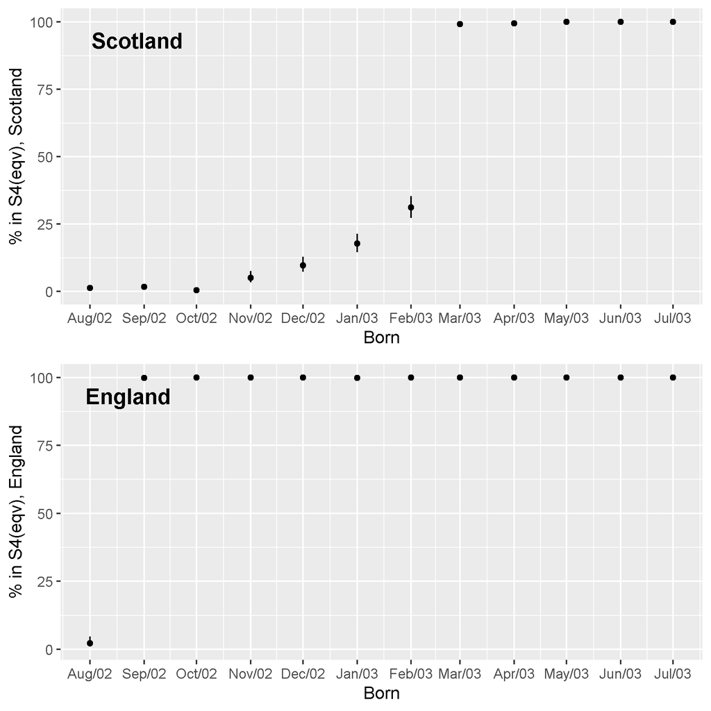

Figure 1 - The probability of being in S4 by date of birth.

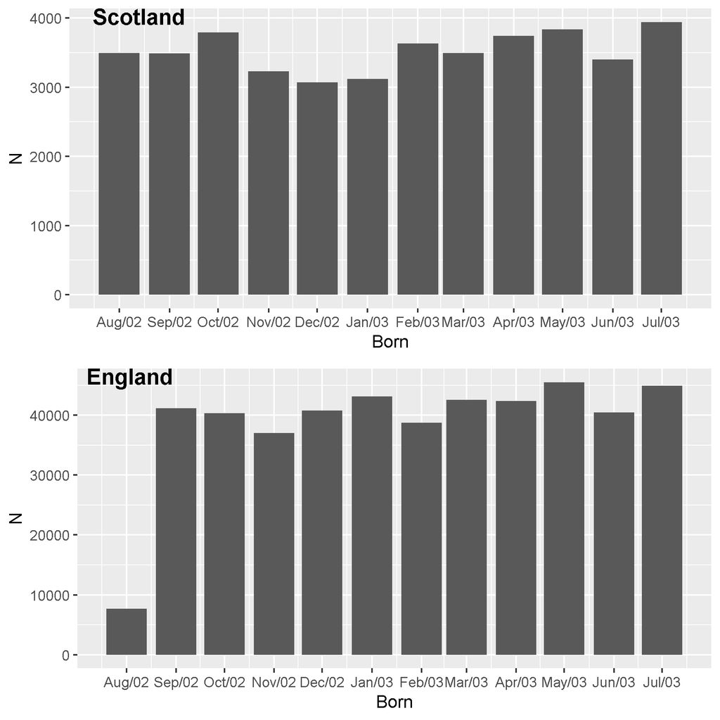

Figure 2 - The distribution of month of birth

We will compare those in S4 to S5 in the month either side of the cut-off ,in other words those born in February and March.

Table 2a: Student characteristics in Scotland PISA 2018 by grade.

| Characteristic | % miss | Overall, N = 42,2431 | S4, N = 20,6231 | S5, N = 21,6201 |
| --- | --- | --- | --- | --- |
| Age | 0% | 15.76 (0.30) | 15.51 (0.17) | 16.00 (0.17) |
| Sex | 0% |  |  |  |
| Female |  | 51% | 49% | 54% |
| Male |  | 49% | 51% | 46% |
| ESCS | 5.4% | 0.23 (0.86) | 0.21 (0.85) | 0.25 (0.86) |
| Highest Occupation of parents (ISEI) | 16% | 58 (21) | 58 (21) | 58 (21) |
| Home possessions scale | 0.1% | 0.14 (0.91) | 0.12 (0.92) | 0.17 (0.90) |
| Highest Education of parents (ISCED) | 12% |  |  |  |
| None |  | <0.1% | <0.1% | 0% |
| ISCED 1 |  | 0.2% | <0.1% | 0.3% |
| ISCED 2 |  | 4.0% | 3.5% | 4.5% |
| ISCED 3B, C |  | 14% | 15% | 13% |
| ISCED 3A, ISCED 4 |  | 17% | 18% | 15% |
| ISCED 5B |  | 13% | 12% | 14% |
| ISCED 5A, 6 |  | 52% | 52% | 53% |

1Mean (SD); %

Table 2b: Student characteristics in England PISA 2018 by grade.

| Characteristic | % miss | Overall, N = 464,6511 | S4, N = 456,9331 | S5, N = 7,7181 |
| --- | --- | --- | --- | --- |
| Age | 0% | 15.76 (0.28) | 15.75 (0.27) | 16.23 (0.06) |
| Sex | 0% |  |  |  |
| Female |  | 52% | 52% | 56% |
| Male |  | 48% | 48% | 44% |
| ESCS | 4.5% | 0.29 (0.92) | 0.29 (0.92) | 0.63 (0.86) |
| Highest Occupation of parents (ISEI) | 18% | 58 (21) | 58 (22) | 65 (19) |
| Home possessions scale | 0.2% | 0.32 (0.99) | 0.31 (0.99) | 0.58 (0.98) |
| Highest Education of parents (ISCED) | 10% |  |  |  |
| None |  | 0.5% | 0.5% | 0% |
| ISCED 1 |  | 0.5% | 0.5% | 1.5% |
| ISCED 2 |  | 2.4% | 2.4% | 1.5% |
| ISCED 3B, C |  | 15% | 15% | 14% |
| ISCED 3A, ISCED 4 |  | 17% | 17% | 8.5% |
| ISCED 5B |  | 17% | 17% | 7.0% |
| ISCED 5A, 6 |  | 48% | 47% | 67% |

1Mean (SD); %

Table 3a: Student characteristics in Scotland PISA 2018 by month

| Characteristic | Feb, N = 3,6331 | March, N = 3,4941 |
| --- | --- | --- |
| Age | 15.73 (0.04) | 15.65 (0.05) |
| Sex |  |  |
| Female | 51% | 48% |
| Male | 49% | 52% |
| ESCS | 0.20 (0.82) | 0.19 (0.85) |
| Highest Occupation of parents (ISEI) | 56 (21) | 56 (22) |
| Home possessions scale | 0.12 (0.85) | 0.07 (0.94) |
| Highest Education of parents (ISCED) |  |  |
| None | 0% | 0% |
| ISCED 1 | 0.3% | 0% |
| ISCED 2 | 4.9% | 2.2% |
| ISCED 3B, C | 11% | 12% |
| ISCED 3A, ISCED 4 | 15% | 20% |
| ISCED 5B | 14% | 13% |
| ISCED 5A, 6 | 55% | 52% |

1Mean (SD); %

Table 3b: Student characteristics in England PISA 2018 by month

| Characteristic | Feb, N = 38,7501 | March, N = 42,5591 |
| --- | --- | --- |
| Age | 15.77 (0.07) | 15.68 (0.07) |
| Sex |  |  |
| Female | 54% | 52% |
| Male | 46% | 48% |
| ESCS | 0.24 (0.92) | 0.26 (0.90) |
| Highest Occupation of parents (ISEI) | 57 (23) | 59 (21) |
| Home possessions scale | 0.31 (0.99) | 0.22 (0.92) |
| Highest Education of parents (ISCED) |  |  |
| None | 0.5% | 0.5% |
| ISCED 1 | 0.4% | 0.5% |
| ISCED 2 | 2.3% | 3.4% |
| ISCED 3B, C | 16% | 14% |
| ISCED 3A, ISCED 4 | 20% | 17% |
| ISCED 5B | 18% | 17% |
| ISCED 5A, 6 | 43% | 47% |

1Mean (SD); %

#### Analysis

We predominately used R and Rstudio for data management, analysis and writing of this protocol and will do so for planned work (R Core Team 2021; RStudio Team 2020). A R markdown file to replicate this protocol is available at [<https://github.com/frankpopham/pisa>](https://github.com/frankpopham/pisa). To incorporate the survey design we use the *survey* and *srvyr* packages (Lumley 2020; Freedman Ellis and Schneider 2020). We will use a version of the instrumental variable analysis, through the *AER* and *survey* packages, that incorporates the survey design (Lumley 2020; Kleiber and Zeileis 2008). All of our outcomes are on a continuous scale or, in one case, ordinal and will be analysed as continuous. Many of the variables have been standardised (to the PISA mean for all countries) to have a mean of 0 and a standard deviation of 1 so we will present all results standardised and assess the magnitude of effects relative to reported or sample standard deviations.

As there are large number of outcomes we shall be cautious to not over emphasise single “significant” results but to take a holistic approach to assessing whether there is a consistent pattern of results with an emphasis on effect sizes. Additionally our analysis may be underpowered due to the number of cases so we will be cautious in claiming no effect when results are imprecise. Although missing data is relatively low we will attempt to adjust for this in sensitivity analysis using inverse probability weighting.

##### Sensitivity analysis

- Extend analysis to include January born pupils in the control group.

#### Outcomes

##### Wellbeing

We will use the PISA framework of wellbeing that covers three main dimensions (cognitive, psychological and social) (Govorova, Benı́tez, and Muñiz 2020). We focus on 14 scales in these domains. These scales, apart from two single question scales, were constructed from a number of questions (see appendix each question) by the PISA study using item response theory (IRT) scaling. The scales have a mean 0 and a standard deviation of 1 across the OECD. Negative scores mean that the score was below the OECD average but could be based on positive responses to the scales questions. The PISA technical report contains full details of the IRT scaling .http://www.oecd.org/pisa/data/pisa2018technicalreport/

Table 4a: Wellbeing Outcomes PISA 2018 Scotland

| Group | Outcomes | % miss | N = 42,244 |
| --- | --- | --- | --- |
| Cognitive | Agree: Your intelligence is something about you that you can't change very much. | 2.6% |  |
|  | Strongly disagree |  | 29% |
|  | Disagree |  | 43% |
|  | Agree |  | 22% |
|  | Strongly agree |  | 6.4% |
| Psychological | Learning goals | 4.8% | -0.05 (0.98) |
|  | Motivation to master tasks | 4.6% | -0.16 (0.93) |
|  | Resilience | 4.7% | -0.15 (0.92) |
|  | Fear of failure | 3.7% | 0.35 (1.03) |
|  | Meaning in life | 5.8% | -0.27 (0.97) |
|  | Positive feelings | 5.2% | -0.28 (0.96) |
|  | Life satisfaction | 3.1% | 7.27 (2.56) |
|  | Attitudes to competition | 3.1% | 0.14 (1.00) |
| Social | Exposure to bullying | 12% | 0.22 (1.07) |
|  | Student competition | 13% | 0.46 (0.89) |
|  | Student co-operation | 14% | -0.09 (0.93) |
|  | Parents' emotional support | 10.0% | 0.23 (0.94) |
|  | Sense of belonging | 5.0% | -0.21 (0.84) |

Table 4b: Wellbeing Outcomes PISA 2018 England

| Group | Outcomes | % miss | N = 464,650 |
| --- | --- | --- | --- |
| Cognitive | Agree: Your intelligence is something about you that you can't change very much. | 3.3% |  |
|  | Strongly disagree |  | 28% |
|  | Disagree |  | 42% |
|  | Agree |  | 22% |
|  | Strongly agree |  | 7.5% |
| Psychological | Learning goals | 4.9% | -0.07 (0.99) |
|  | Motivation to master tasks | 5.5% | -0.16 (0.94) |
|  | Resilience | 4.9% | -0.18 (0.95) |
|  | Fear of failure | 3.9% | 0.27 (1.03) |
|  | Meaning in life | 5.9% | -0.26 (1.02) |
|  | Positive feelings | 5.1% | -0.29 (0.97) |
|  | Life satisfaction | 3.5% | 7.14 (2.67) |
|  | Attitudes to competition | 3.6% | 0.17 (0.99) |
| Social | Exposure to bullying | 8.6% | 0.24 (1.05) |
|  | Student competition | 7.9% | 0.30 (0.94) |
|  | Student co-operation | 11% | -0.15 (0.92) |
|  | Parents' emotional support | 5.9% | 0.06 (1.00) |
|  | Sense of belonging | 5.3% | -0.18 (0.91) |

##### Educational performance

PISA measures Educational performance in three core subject areas, maths, reading and science. As students answer different but overlapping subsets of the questions for each subject, multiple imputation is used to combine the 10 plausible values for each student on each scale in PISA. We will use *micombine* to do this (Lumley 2019).

Table 5a: PISA assessment scores for Scotland 2018

| Subject | Mean | LCI | UCI |
| --- | --- | --- | --- |
| Maths | 492 | 487 | 498 |
| Reading | 508 | 504 | 511 |
| Science | 493 | 487 | 499 |

Table 5b: PISA assessment scores for England 2018

| Subject | Mean | LCI | UCI |
| --- | --- | --- | --- |
| Maths | 507 | 504 | 510 |
| Reading | 509 | 506 | 512 |
| Science | 511 | 508 | 514 |

#### Appendix

**Cognitive**

Table A1: Cognitive wellbeing Scotland

| Outcomes | % miss | N = 42,2441 |
| --- | --- | --- |
| Agree: Your intelligence is something about you that you can't change very much. | 2.6% |  |
| Strongly disagree |  | 29% |
| Disagree |  | 43% |
| Agree |  | 22% |
| Strongly agree |  | 6.4% |

1%

Table A2: Cognitive wellbeing England

| Outcomes | % miss | N = 464,6501 |
| --- | --- | --- |
| Agree: Your intelligence is something about you that you can't change very much. | 3.3% |  |
| Strongly disagree |  | 28% |
| Disagree |  | 42% |
| Agree |  | 22% |
| Strongly agree |  | 7.5% |

1%

**Psychological**

Students were asked about the following eight domains of psychological well being most of which contain a number of questions

- Learning goals
- Motivation to master tasks
- Resilience (or self-efficacy)
- Fear of failure
- Meaning in life
- Positive feelings
- Life satisfaction
- Attitudes to competition

Table A3: Learning goals Scotland

| Outcomes | % miss | N = 42,2441 |
| --- | --- | --- |
| How true for you: My goal is to learn as much as possible. | 3.5% |  |
| Not at all true of me |  | 3.4% |
| Slightly true of me |  | 11% |
| Moderately true of me |  | 35% |
| Very true of me |  | 34% |
| Extremely true of me |  | 16% |
| How true for you: My goal is to completely master the material presented in my classes. | 3.8% |  |
| Not at all true of me |  | 11% |
| Slightly true of me |  | 20% |
| Moderately true of me |  | 36% |
| Very true of me |  | 22% |
| Extremely true of me |  | 11% |
| How true for you: My goal is to understand the content of my classes as thoroughly as possible. | 4.4% |  |
| Not at all true of me |  | 3.6% |
| Slightly true of me |  | 10% |
| Moderately true of me |  | 24% |
| Very true of me |  | 40% |
| Extremely true of me |  | 22% |

1%

Table A4: Learning goals England

| Outcomes | % miss | N = 464,6501 |
| --- | --- | --- |
| How true for you: My goal is to learn as much as possible. | 4.1% |  |
| Not at all true of me |  | 3.6% |
| Slightly true of me |  | 14% |
| Moderately true of me |  | 36% |
| Very true of me |  | 32% |
| Extremely true of me |  | 15% |
| How true for you: My goal is to completely master the material presented in my classes. | 4.3% |  |
| Not at all true of me |  | 10% |
| Slightly true of me |  | 21% |
| Moderately true of me |  | 35% |
| Very true of me |  | 22% |
| Extremely true of me |  | 12% |
| How true for you: My goal is to understand the content of my classes as thoroughly as possible. | 4.6% |  |
| Not at all true of me |  | 4.0% |
| Slightly true of me |  | 10% |
| Moderately true of me |  | 28% |
| Very true of me |  | 37% |
| Extremely true of me |  | 21% |

1%

Table A5: Motivation to master tasks Scotland

| Outcomes | % miss | N = 42,2441 |
| --- | --- | --- |
| Agree: I find satisfaction in working as hard as I can. | 3.5% |  |
| Strongly disagree |  | 3.3% |
| Disagree |  | 19% |
| Agree |  | 56% |
| Strongly agree |  | 21% |
| Agree: Once I start a task, I persist until it is finished. | 3.7% |  |
| Strongly disagree |  | 3.8% |
| Disagree |  | 33% |
| Agree |  | 50% |
| Strongly agree |  | 14% |
| Agree: Part of the enjoyment I get from doing things is when I improve on my past performance. | 3.8% |  |
| Strongly disagree |  | 2.3% |
| Disagree |  | 17% |
| Agree |  | 58% |
| Strongly agree |  | 22% |
| Agree: If I am not good at something, I would rather keep struggling to master it than move on to something I may [...] | 4.4% |  |
| Strongly disagree |  | 8.9% |
| Disagree |  | 36% |
| Agree |  | 42% |
| Strongly agree |  | 13% |

1%

Table A6: Motivation to master tasks England

| Outcomes | % miss | N = 464,6501 |
| --- | --- | --- |
| Agree: I find satisfaction in working as hard as I can. | 4.1% |  |
| Strongly disagree |  | 3.6% |
| Disagree |  | 19% |
| Agree |  | 57% |
| Strongly agree |  | 20% |
| Agree: Once I start a task, I persist until it is finished. | 4.4% |  |
| Strongly disagree |  | 3.9% |
| Disagree |  | 31% |
| Agree |  | 49% |
| Strongly agree |  | 16% |
| Agree: Part of the enjoyment I get from doing things is when I improve on my past performance. | 4.8% |  |
| Strongly disagree |  | 2.7% |
| Disagree |  | 17% |
| Agree |  | 58% |
| Strongly agree |  | 22% |
| Agree: If I am not good at something, I would rather keep struggling to master it than move on to something I may [...] | 4.8% |  |
| Strongly disagree |  | 9.3% |
| Disagree |  | 36% |
| Agree |  | 42% |
| Strongly agree |  | 13% |

1%

Table A7: Resilience (or self-efficacy) Scotland

| Outcomes | % miss | N = 42,2441 |
| --- | --- | --- |
| Agree: I usually manage one way or another. | 4.8% |  |
| Strongly disagree |  | 1.4% |
| Disagree |  | 7.5% |
| Agree |  | 74% |
| Strongly agree |  | 17% |
| Agree: I feel proud that I have accomplished things. | 5.0% |  |
| Strongly disagree |  | 1.3% |
| Disagree |  | 11% |
| Agree |  | 62% |
| Strongly agree |  | 25% |
| Agree: I feel that I can handle many things at a time. | 4.9% |  |
| Strongly disagree |  | 5.6% |
| Disagree |  | 26% |
| Agree |  | 55% |
| Strongly agree |  | 13% |
| Agree: My belief in myself gets me through hard times. | 5.3% |  |
| Strongly disagree |  | 7.9% |
| Disagree |  | 32% |
| Agree |  | 48% |
| Strongly agree |  | 13% |
| Agree: When I’m in a difficult situation, I can usually find my way out of it. | 5.3% |  |
| Strongly disagree |  | 3.0% |
| Disagree |  | 14% |
| Agree |  | 64% |
| Strongly agree |  | 18% |

1%

Table A8: Resilience (or self-efficacy) England

| Outcomes | % miss | N = 464,6501 |
| --- | --- | --- |
| Agree: I usually manage one way or another. | 5.2% |  |
| Strongly disagree |  | 1.4% |
| Disagree |  | 8.4% |
| Agree |  | 73% |
| Strongly agree |  | 17% |
| Agree: I feel proud that I have accomplished things. | 5.2% |  |
| Strongly disagree |  | 2.2% |
| Disagree |  | 12% |
| Agree |  | 62% |
| Strongly agree |  | 24% |
| Agree: I feel that I can handle many things at a time. | 5.4% |  |
| Strongly disagree |  | 5.3% |
| Disagree |  | 29% |
| Agree |  | 52% |
| Strongly agree |  | 14% |
| Agree: My belief in myself gets me through hard times. | 5.5% |  |
| Strongly disagree |  | 9.9% |
| Disagree |  | 32% |
| Agree |  | 43% |
| Strongly agree |  | 15% |
| Agree: When I’m in a difficult situation, I can usually find my way out of it. | 5.4% |  |
| Strongly disagree |  | 3.6% |
| Disagree |  | 17% |
| Agree |  | 62% |
| Strongly agree |  | 18% |

1%

Table A9: Fear of failure Scotland

| Outcomes | % miss | N = 42,2441 |
| --- | --- | --- |
| Agree: When I am failing, I worry about what others think of me. | 3.5% |  |
| Strongly disagree |  | 10% |
| Disagree |  | 24% |
| Agree |  | 40% |
| Strongly agree |  | 26% |
| Agree: When I am failing, I am afraid that I might not have enough talent. | 3.2% |  |
| Strongly disagree |  | 9.3% |
| Disagree |  | 24% |
| Agree |  | 41% |
| Strongly agree |  | 25% |
| Agree: When I am failing, this makes me doubt my plans for the future. | 3.4% |  |
| Strongly disagree |  | 7.9% |
| Disagree |  | 20% |
| Agree |  | 38% |
| Strongly agree |  | 34% |

1%

Table A10: Fear of failure England

| Outcomes | % miss | N = 464,6501 |
| --- | --- | --- |
| Agree: When I am failing, I worry about what others think of me. | 3.6% |  |
| Strongly disagree |  | 12% |
| Disagree |  | 25% |
| Agree |  | 40% |
| Strongly agree |  | 23% |
| Agree: When I am failing, I am afraid that I might not have enough talent. | 3.8% |  |
| Strongly disagree |  | 10% |
| Disagree |  | 27% |
| Agree |  | 40% |
| Strongly agree |  | 23% |
| Agree: When I am failing, this makes me doubt my plans for the future. | 3.7% |  |
| Strongly disagree |  | 9.2% |
| Disagree |  | 20% |
| Agree |  | 38% |
| Strongly agree |  | 32% |

1%

Table A11: Meaning in life Scotland

| Outcomes | % miss | N = 42,2441 |
| --- | --- | --- |
| Agree: My life has clear meaning or purpose. | 4.2% |  |
| Strongly disagree |  | 11% |
| Disagree |  | 32% |
| Agree |  | 44% |
| Strongly agree |  | 12% |
| Agree: I have discovered a satisfactory meaning in life. | 5.0% |  |
| Strongly disagree |  | 11% |
| Disagree |  | 39% |
| Agree |  | 41% |
| Strongly agree |  | 9.7% |
| Agree: I have a clear sense of what gives meaning to my life. | 5.2% |  |
| Strongly disagree |  | 10% |
| Disagree |  | 33% |
| Agree |  | 44% |
| Strongly agree |  | 13% |

1%

Table A12: Meaning in life England

| Outcomes | % miss | N = 464,6501 |
| --- | --- | --- |
| Agree: My life has clear meaning or purpose. | 4.8% |  |
| Strongly disagree |  | 12% |
| Disagree |  | 31% |
| Agree |  | 43% |
| Strongly agree |  | 14% |
| Agree: I have discovered a satisfactory meaning in life. | 5.3% |  |
| Strongly disagree |  | 13% |
| Disagree |  | 36% |
| Agree |  | 40% |
| Strongly agree |  | 11% |
| Agree: I have a clear sense of what gives meaning to my life. | 5.3% |  |
| Strongly disagree |  | 12% |
| Disagree |  | 30% |
| Agree |  | 43% |
| Strongly agree |  | 14% |

1%

Table A13: Positive feelings Scotland

| Outcomes | % miss | N = 42,2441 |
| --- | --- | --- |
| Thinking about yourself and how you normally feel: how often do you feel as described below? Happy | 3.1% |  |
| Never |  | 1.4% |
| Rarely |  | 5.3% |
| Sometimes |  | 57% |
| Always |  | 36% |
| Thinking about yourself and how you normally feel: how often do you feel as described below? Scared | 3.7% |  |
| Never |  | 12% |
| Rarely |  | 48% |
| Sometimes |  | 36% |
| Always |  | 4.1% |
| Thinking about yourself and how you normally feel: how often do you feel as described below? Lively | 4.1% |  |
| Never |  | 2.6% |
| Rarely |  | 16% |
| Sometimes |  | 54% |
| Always |  | 27% |
| Thinking about yourself and how you normally feel: how often do you feel as described below? Miserable | 3.8% |  |
| Never |  | 12% |
| Rarely |  | 41% |
| Sometimes |  | 41% |
| Always |  | 6.0% |
| Thinking about yourself and how you normally feel: how often do you feel as described below? Proud | 3.9% |  |
| Never |  | 4.6% |
| Rarely |  | 28% |
| Sometimes |  | 55% |
| Always |  | 12% |
| Thinking about yourself and how you normally feel: how often do you feel as described below? Afraid | 3.8% |  |
| Never |  | 5.6% |
| Rarely |  | 24% |
| Sometimes |  | 49% |
| Always |  | 21% |
| Thinking about yourself and how you normally feel: how often do you feel as described below? Joyful | 4.2% |  |
| Never |  | 2.2% |
| Rarely |  | 16% |
| Sometimes |  | 60% |
| Always |  | 22% |
| Thinking about yourself and how you normally feel: how often do you feel as described below? Sad | 3.6% |  |
| Never |  | 4.9% |
| Rarely |  | 32% |
| Sometimes |  | 55% |
| Always |  | 8.3% |
| Thinking about yourself and how you normally feel: how often do you feel as described below? Cheerful | 4.3% |  |
| Never |  | 2.2% |
| Rarely |  | 13% |
| Sometimes |  | 59% |
| Always |  | 26% |

1%

Table A14: Positive feelings England

| Outcomes | % miss | N = 464,6501 |
| --- | --- | --- |
| Thinking about yourself and how you normally feel: how often do you feel as described below? Happy | 3.8% |  |
| Never |  | 1.2% |
| Rarely |  | 6.1% |
| Sometimes |  | 58% |
| Always |  | 35% |
| Thinking about yourself and how you normally feel: how often do you feel as described below? Scared | 4.2% |  |
| Never |  | 13% |
| Rarely |  | 48% |
| Sometimes |  | 33% |
| Always |  | 5.1% |
| Thinking about yourself and how you normally feel: how often do you feel as described below? Lively | 4.5% |  |
| Never |  | 1.9% |
| Rarely |  | 15% |
| Sometimes |  | 54% |
| Always |  | 29% |
| Thinking about yourself and how you normally feel: how often do you feel as described below? Miserable | 4.4% |  |
| Never |  | 9.7% |
| Rarely |  | 37% |
| Sometimes |  | 46% |
| Always |  | 7.8% |
| Thinking about yourself and how you normally feel: how often do you feel as described below? Proud | 4.3% |  |
| Never |  | 5.8% |
| Rarely |  | 30% |
| Sometimes |  | 53% |
| Always |  | 12% |
| Thinking about yourself and how you normally feel: how often do you feel as described below? Afraid | 4.3% |  |
| Never |  | 6.8% |
| Rarely |  | 28% |
| Sometimes |  | 46% |
| Always |  | 20% |
| Thinking about yourself and how you normally feel: how often do you feel as described below? Joyful | 4.5% |  |
| Never |  | 2.0% |
| Rarely |  | 16% |
| Sometimes |  | 59% |
| Always |  | 23% |
| Thinking about yourself and how you normally feel: how often do you feel as described below? Sad | 4.5% |  |
| Never |  | 6.9% |
| Rarely |  | 33% |
| Sometimes |  | 51% |
| Always |  | 8.5% |
| Thinking about yourself and how you normally feel: how often do you feel as described below? Cheerful | 4.3% |  |
| Never |  | 2.3% |
| Rarely |  | 14% |
| Sometimes |  | 58% |
| Always |  | 26% |

1%

Table A15: Life satisfaction Scotland

| Outcomes | % miss | N = 42,2441 |
| --- | --- | --- |
| Life satisfaction | 3.1% | 7.27 (2.56) |

1Mean (SD)

Table A16: Life satisfaction England

| Outcomes | % miss | N = 464,6501 |
| --- | --- | --- |
| Life satisfaction | 3.5% | 7.14 (2.67) |

1Mean (SD)

Table A17: Attitudes to competition Scotland

| Outcomes | % miss | N = 42,2441 |
| --- | --- | --- |
| Agree: I enjoy working in situations involving competition with others. | 2.4% |  |
| Strongly disagree |  | 6.9% |
| Disagree |  | 22% |
| Agree |  | 48% |
| Strongly agree |  | 23% |
| Agree: It is important for me to perform better than other people on a task. | 2.7% |  |
| Strongly disagree |  | 5.9% |
| Disagree |  | 34% |
| Agree |  | 42% |
| Strongly agree |  | 18% |
| Agree: I try harder when I’m in competition with other people. | 2.7% |  |
| Strongly disagree |  | 5.4% |
| Disagree |  | 16% |
| Agree |  | 46% |
| Strongly agree |  | 32% |

1%

Table A18: Attitudes to competition England

| Outcomes | % miss | N = 464,6501 |
| --- | --- | --- |
| Agree: I enjoy working in situations involving competition with others. | 2.9% |  |
| Strongly disagree |  | 7.4% |
| Disagree |  | 24% |
| Agree |  | 47% |
| Strongly agree |  | 21% |
| Agree: It is important for me to perform better than other people on a task. | 3.2% |  |
| Strongly disagree |  | 5.6% |
| Disagree |  | 31% |
| Agree |  | 42% |
| Strongly agree |  | 22% |
| Agree: I try harder when I’m in competition with other people. | 3.1% |  |
| Strongly disagree |  | 4.3% |
| Disagree |  | 16% |
| Agree |  | 47% |
| Strongly agree |  | 32% |

1%

**Social**

- Exposure to bullying
- Student competition
- Student co-operation
- Parents’ emotional support
- Sense of belonging scale

Table A19: Exposure to bullying Scotland

| Outcomes | % miss | N = 42,2441 |
| --- | --- | --- |
| During the past 12 months, how often: Other students left me out of things on purpose. | 11% |  |
| Never or almost never |  | 65% |
| A few times a year |  | 24% |
| A few times a month |  | 7.8% |
| Once a week or more |  | 3.7% |
| During the past 12 months, how often: Other students made fun of me. | 11% |  |
| Never or almost never |  | 52% |
| A few times a year |  | 28% |
| A few times a month |  | 12% |
| Once a week or more |  | 8.1% |
| During the past 12 months, how often: I was threatened by other students. | 11% |  |
| Never or almost never |  | 79% |
| A few times a year |  | 14% |
| A few times a month |  | 4.7% |
| Once a week or more |  | 2.6% |
| During the past 12 months, how often: Other students took away or destroyed things that belonged to me. | 11% |  |
| Never or almost never |  | 87% |
| A few times a year |  | 8.5% |
| A few times a month |  | 2.7% |
| Once a week or more |  | 1.7% |
| During the past 12 months, how often: I got hit or pushed around by other students. | 11% |  |
| Never or almost never |  | 82% |
| A few times a year |  | 12% |
| A few times a month |  | 3.9% |
| Once a week or more |  | 2.7% |
| During the past 12 months, how often: Other students spread nasty rumours about me. | 11% |  |
| Never or almost never |  | 71% |
| A few times a year |  | 20% |
| A few times a month |  | 5.7% |
| Once a week or more |  | 3.7% |

1%

Table A20: Exposure to bullying England

| Outcomes | % miss | N = 464,6501 |
| --- | --- | --- |
| During the past 12 months, how often: Other students left me out of things on purpose. | 7.8% |  |
| Never or almost never |  | 65% |
| A few times a year |  | 25% |
| A few times a month |  | 6.9% |
| Once a week or more |  | 3.6% |
| During the past 12 months, how often: Other students made fun of me. | 8.0% |  |
| Never or almost never |  | 51% |
| A few times a year |  | 30% |
| A few times a month |  | 11% |
| Once a week or more |  | 8.4% |
| During the past 12 months, how often: I was threatened by other students. | 8.2% |  |
| Never or almost never |  | 80% |
| A few times a year |  | 13% |
| A few times a month |  | 4.2% |
| Once a week or more |  | 2.6% |
| During the past 12 months, how often: Other students took away or destroyed things that belonged to me. | 8.3% |  |
| Never or almost never |  | 86% |
| A few times a year |  | 9.9% |
| A few times a month |  | 2.9% |
| Once a week or more |  | 1.6% |
| During the past 12 months, how often: I got hit or pushed around by other students. | 8.1% |  |
| Never or almost never |  | 82% |
| A few times a year |  | 12% |
| A few times a month |  | 3.7% |
| Once a week or more |  | 2.5% |
| During the past 12 months, how often: Other students spread nasty rumours about me. | 8.3% |  |
| Never or almost never |  | 70% |
| A few times a year |  | 20% |
| A few times a month |  | 6.1% |
| Once a week or more |  | 3.9% |

1%

Table A21: Student competition Scotland

| Outcomes | % miss | N = 42,2441 |
| --- | --- | --- |
| Think about your school, how true: Students seem to value competition. | 12% |  |
| Not at all true |  | 2.9% |
| Slightly true |  | 32% |
| Very true |  | 48% |
| Extremely true |  | 17% |
| Think about your school, how true: It seems that students are competing with each other. | 12% |  |
| Not at all true |  | 2.0% |
| Slightly true |  | 24% |
| Very true |  | 51% |
| Extremely true |  | 22% |
| Think about your school, how true: Students seem to share the feeling that competing with each other is important. | 12% |  |
| Not at all true |  | 6.0% |
| Slightly true |  | 33% |
| Very true |  | 46% |
| Extremely true |  | 15% |
| Think about your school, how true: Students feel that they are being compared with others. | 12% |  |
| Not at all true |  | 4.7% |
| Slightly true |  | 22% |
| Very true |  | 40% |
| Extremely true |  | 32% |

1%

Table A22: Student competition England

| Outcomes | % miss | N = 464,6501 |
| --- | --- | --- |
| Think about your school, how true: Students seem to value competition. | 6.8% |  |
| Not at all true |  | 4.5% |
| Slightly true |  | 38% |
| Very true |  | 43% |
| Extremely true |  | 15% |
| Think about your school, how true: It seems that students are competing with each other. | 6.9% |  |
| Not at all true |  | 4.1% |
| Slightly true |  | 30% |
| Very true |  | 47% |
| Extremely true |  | 19% |
| Think about your school, how true: Students seem to share the feeling that competing with each other is important. | 7.3% |  |
| Not at all true |  | 10% |
| Slightly true |  | 36% |
| Very true |  | 40% |
| Extremely true |  | 14% |
| Think about your school, how true: Students feel that they are being compared with others. | 7.1% |  |
| Not at all true |  | 6.1% |
| Slightly true |  | 26% |
| Very true |  | 35% |
| Extremely true |  | 33% |

1%

Table A23: Student co-operation Scotland

| Outcomes | % miss | N = 42,2441 |
| --- | --- | --- |
| Think about your school, how true: Students seem to value cooperation. | 13% |  |
| Not at all true |  | 5.4% |
| Slightly true |  | 43% |
| Very true |  | 43% |
| Extremely true |  | 8.7% |
| Think about your school, how true: It seems that students are cooperating with each other. | 13% |  |
| Not at all true |  | 4.1% |
| Slightly true |  | 35% |
| Very true |  | 51% |
| Extremely true |  | 9.3% |
| Think about your school, how true: Students seem to share the feeling that cooperating with each other is important. | 14% |  |
| Not at all true |  | 6.9% |
| Slightly true |  | 39% |
| Very true |  | 45% |
| Extremely true |  | 9.3% |
| Think about your school, how true: Students feel that they are encouraged to cooperate with others. | 14% |  |
| Not at all true |  | 6.2% |
| Slightly true |  | 33% |
| Very true |  | 49% |
| Extremely true |  | 12% |

1%

Table A24: Student co-operation England

| Outcomes | % miss | N = 464,6501 |
| --- | --- | --- |
| Think about your school, how true: Students seem to value cooperation. | 10% |  |
| Not at all true |  | 6.0% |
| Slightly true |  | 45% |
| Very true |  | 41% |
| Extremely true |  | 7.6% |
| Think about your school, how true: It seems that students are cooperating with each other. | 10% |  |
| Not at all true |  | 4.3% |
| Slightly true |  | 37% |
| Very true |  | 49% |
| Extremely true |  | 9.4% |
| Think about your school, how true: Students seem to share the feeling that cooperating with each other is important. | 10% |  |
| Not at all true |  | 7.7% |
| Slightly true |  | 41% |
| Very true |  | 43% |
| Extremely true |  | 8.3% |
| Think about your school, how true: Students feel that they are encouraged to cooperate with others. | 11% |  |
| Not at all true |  | 7.0% |
| Slightly true |  | 37% |
| Very true |  | 46% |
| Extremely true |  | 9.8% |

1%

Table A25: Parents' emotional support Scotland

| Outcomes | % miss | N = 42,2441 |
| --- | --- | --- |
| Thinking about <this academic year>: My parents support my educational efforts and achievements. | 9.0% |  |
| Strongly disagree |  | 2.3% |
| Disagree |  | 3.1% |
| Agree |  | 33% |
| Strongly agree |  | 62% |
| Thinking about <this academic year>: My parents support me when I am facing difficulties at school. | 9.4% |  |
| Strongly disagree |  | 2.8% |
| Disagree |  | 7.0% |
| Agree |  | 37% |
| Strongly agree |  | 53% |
| Thinking about <this academic year>: My parents encourage me to be confident. | 9.5% |  |
| Strongly disagree |  | 2.7% |
| Disagree |  | 6.2% |
| Agree |  | 35% |
| Strongly agree |  | 56% |

1%

Table A26: Parents' emotional support England

| Outcomes | % miss | N = 464,6501 |
| --- | --- | --- |
| Thinking about <this academic year>: My parents support my educational efforts and achievements. | 5.3% |  |
| Strongly disagree |  | 3.8% |
| Disagree |  | 4.6% |
| Agree |  | 39% |
| Strongly agree |  | 53% |
| Thinking about <this academic year>: My parents support me when I am facing difficulties at school. | 5.6% |  |
| Strongly disagree |  | 4.5% |
| Disagree |  | 10% |
| Agree |  | 40% |
| Strongly agree |  | 46% |
| Thinking about <this academic year>: My parents encourage me to be confident. | 5.6% |  |
| Strongly disagree |  | 4.1% |
| Disagree |  | 7.0% |
| Agree |  | 39% |
| Strongly agree |  | 50% |

1%

Table A27: Sense of belonging Scotland

| Outcomes | % miss | N = 42,2441 |
| --- | --- | --- |
| Thinking about your school: I feel like an outsider (or left out of things) at school. | 5.2% |  |
| Strongly agree |  | 4.9% |
| Agree |  | 19% |
| Disagree |  | 51% |
| Strongly disagree |  | 25% |
| Thinking about your school: I make friends easily at school. | 5.4% |  |
| Strongly agree |  | 16% |
| Agree |  | 59% |
| Disagree |  | 20% |
| Strongly disagree |  | 4.3% |
| Thinking about your school: I feel like I belong at school. | 5.8% |  |
| Strongly agree |  | 9.5% |
| Agree |  | 55% |
| Disagree |  | 27% |
| Strongly disagree |  | 8.5% |
| Thinking about your school: I feel awkward and out of place in my school. | 5.8% |  |
| Strongly agree |  | 5.2% |
| Agree |  | 20% |
| Disagree |  | 54% |
| Strongly disagree |  | 21% |
| Thinking about your school: Other students seem to like me. | 6.1% |  |
| Strongly agree |  | 13% |
| Agree |  | 74% |
| Disagree |  | 10% |
| Strongly disagree |  | 2.6% |
| Thinking about your school: I feel lonely at school. | 5.9% |  |
| Strongly agree |  | 4.0% |
| Agree |  | 11% |
| Disagree |  | 49% |
| Strongly disagree |  | 36% |

1%

Table A28: Sense of belonging England

| Outcomes | % miss | N = 464,6501 |
| --- | --- | --- |
| Thinking about your school: I feel like an outsider (or left out of things) at school. | 5.8% |  |
| Strongly agree |  | 6.3% |
| Agree |  | 19% |
| Disagree |  | 49% |
| Strongly disagree |  | 26% |
| Thinking about your school: I make friends easily at school. | 5.7% |  |
| Strongly agree |  | 16% |
| Agree |  | 57% |
| Disagree |  | 22% |
| Strongly disagree |  | 5.0% |
| Thinking about your school: I feel like I belong at school. | 6.1% |  |
| Strongly agree |  | 12% |
| Agree |  | 51% |
| Disagree |  | 28% |
| Strongly disagree |  | 9.7% |
| Thinking about your school: I feel awkward and out of place in my school. | 6.1% |  |
| Strongly agree |  | 5.9% |
| Agree |  | 17% |
| Disagree |  | 51% |
| Strongly disagree |  | 26% |
| Thinking about your school: Other students seem to like me. | 6.4% |  |
| Strongly agree |  | 15% |
| Agree |  | 70% |
| Disagree |  | 11% |
| Strongly disagree |  | 3.4% |
| Thinking about your school: I feel lonely at school. | 6.1% |  |
| Strongly agree |  | 4.8% |
| Agree |  | 11% |
| Disagree |  | 46% |
| Strongly disagree |  | 38% |

1%

#### References

Benton, Tom. 2014. “The Relationship Between Time in Education and Achievement in PISA in England.” In *British Educational Research Association Conference, London. Retrieved from Http://Cambridgeassessment. Org. Uk/Images/178785-the-Relationship-Between-Time-in-Educationand-Achievement-in-Pisa-in-England. Pdf Evidence from PISA*.

Buckles, Kasey S., and Daniel M. Hungerman. 2013. “Season of Birth and Later Outcomes: Old Questions, New Answers.” *The Review of Economics and Statistics* 95 (3): 711–24. https://doi.org/10.1162/REST_a_00314.

Chen, Kelly, Nicole Fortin, and Shelley Phipps. 2015. “Young in Class: Implications for Inattentive/Hyperactive Behaviour of Canadian Boys and Girls.” *Canadian Journal of Economics/Revue Canadienne d’économique* 48 (5): 1601–34. https://doi.org/https://doi.org/10.1111/caje.12174.

Cornelissen, Thomas, and Christian Dustmann. 2019. “Early School Exposure, Test Scores, and Noncognitive Outcomes.” *American Economic Journal: Economic Policy* 11 (2): 35–63. https://doi.org/10.1257/pol.20170641.

Crawford, Claire, Lorraine Dearden, and Ellen Greaves. 2014. “The Drivers of Month-of-Birth Differences in Children’s Cognitive and Non-Cognitive Skills.” *Journal of the Royal Statistical Society. Series A, (Statistics in Society)* 177 (4): 829—860. https://doi.org/10.1111/rssa.12071.

Dee, Thomas S., and Hans Henrik Sievertsen. 2018. “The Gift of Time? School Starting Age and Mental Health.” *Health Economics* 27 (5): 781–802. https://doi.org/https://doi.org/10.1002/hec.3638.

Elder, Todd E. 2010. “The Importance of Relative Standards in ADHD Diagnoses: Evidence Based on Exact Birth Dates.” *Journal of Health Economics* 29 (5): 641–56. https://doi.org/https://doi.org/10.1016/j.jhealeco.2010.06.003.

Evans, William N., Melinda S. Morrill, and Stephen T. Parente. 2010. “Measuring Inappropriate Medical Diagnosis and Treatment in Survey Data: The Case of ADHD Among School-Age Children.” *Journal of Health Economics* 29 (5): 657–73. https://doi.org/https://doi.org/10.1016/j.jhealeco.2010.07.005.

Freedman Ellis, Greg, and Ben Schneider. 2020. *Srvyr: Dplyr-Like Syntax for Summary Statistics of Survey Data*. https://CRAN.R-project.org/package=srvyr.

Govorova, Elena, Isabel Benı́tez, and José Muñiz. 2020. “Predicting Student Well-Being: Network Analysis Based on PISA 2018.” *International Journal of Environmental Research and Public Health* 17 (11): 4014.

Hernán, Miguel A, and James M Robins. 2020. “Causal Inference.” CRC Boca Raton, FL;

Kleiber, Christian, and Achim Zeileis. 2008. *Applied Econometrics with R*. New York: Springer-Verlag. https://CRAN.R-project.org/package=AER.

Lumley, Thomas. 2019. *Mitools: Tools for Multiple Imputation of Missing Data*. https://CRAN.R-project.org/package=mitools.

———. 2020. *Survey: Analysis of Complex Survey Samples*. http://r-survey.r-forge.r-project.org/survey/.

Luyten, Hans, Jules Peschar, and Robert Coe. 2008. “Effects of Schooling on Reading Performance, Reading Engagement, and Reading Activities of 15-Year-Olds in England.” *American Educational Research Journal* 45 (2): 319–42. https://doi.org/10.3102/0002831207313345.

OECD. 2016. *PISA 2015 Results (Volume II)*. https://doi.org/https://doi.org/https://doi.org/10.1787/9789264267510-en.

R Core Team. 2021. *R: A Language and Environment for Statistical Computing*. Vienna, Austria: R Foundation for Statistical Computing. https://www.R-project.org/.

RStudio Team. 2020. *RStudio: Integrated Development Environment for r*. Boston, MA: RStudio, PBC. http://www.rstudio.com/.

Schwandt, Hannes, and Amelie Wuppermann. 2016. “The Youngest Get the Pill: ADHD Misdiagnosis in Germany, Its Regional Correlates and International Comparison.” *Labour Economics* 43: 72–86. https://doi.org/https://doi.org/10.1016/j.labeco.2016.05.018.

Scottish Government. 2012. “Growing up in Scotland: Early Experiences of Primary School.” https://www.gov.scot/binaries/content/documents/govscot/publications/research-and-analysis/2012/05/growing-up-scotland-early-experiences-primary-school/documents/00392709-pdf/00392709-pdf/govscot.

———. 2018a. “Child and Adolscent Health and Wellbeing in Scotland - Evidence Review.” https://www.gov.scot/binaries/content/documents/govscot/publications/research-and-analysis/2018/09/child-adolescent-health-wellbeing-scotland-evidence-review/documents/00540155-pdf/00540155-pdf/govscot.

———. 2018b. “Programme for International Student Assessment (PISA) 2018: Highlights from Scotland’s Results.” https://www.gov.scot/publications/programme-international-student-assessment-pisa-2018-highlights-scotlands-results/.

———. 2020. “Deferred Entry to Primary School: Statistics.” https://www.gov.scot/publications/deferred-entry-primary-school-statistics/.

Suziedelyte, Agne, and Anna Zhu. 2015. “Does Early Schooling Narrow Outcome Gaps for Advantaged and Disadvantaged Children?” *Economics of Education Review* 45: 76–88. https://doi.org/https://doi.org/10.1016/j.econedurev.2015.02.001.